# Open Case Studies: Exploring global patterns of obesity across rural and urban regions

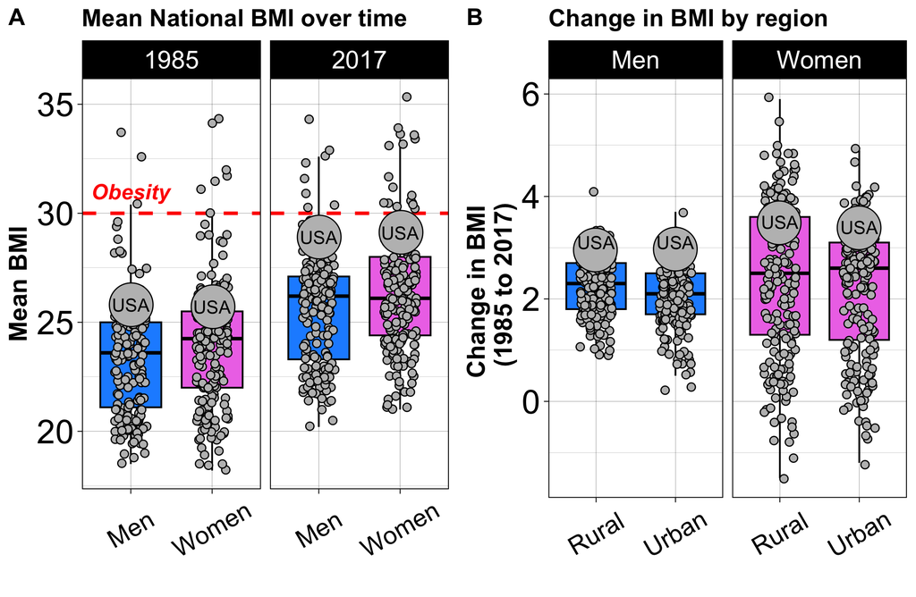

**Disclaimer**: The purpose of the [Open Case Studies](https://opencasestudies.github.io) project is **to demonstrate the use of various data science methods, tools, and software in the context of messy, real-world data**. A given case study does not cover all aspects of the research process, is not claiming to be the most appropriate way to analyze a given dataset, and should not be used in the context of making policy decisions without external consultation from scientific experts.

This work is licensed under the Creative Commons Attribution-NonCommercial 3.0 [(CC BY-NC 3.0)](https://creativecommons.org/licenses/by-nc/3.0/us/) United States License.

To cite this case study please use:

Wright, Carrie and Meng, Qier and Jager, Leah and Taub, Margaret and Hicks, Stephanie. (2020). https://github.com/opencasestudies/ocs-bp-rural-and-urban-obesity. Exploring global patterns of obesity across rural and urban regions (Version v1.0.0).

To access the GitHub Repository for this case study see here: https://github.com/opencasestudies/ocs-bp-rural-and-urban-obesity.

You may also access and download the data using our `OCSdata` package. To learn more about this package including examples, see this [link](https://github.com/opencasestudies/OCSdata). Here is how you would install this package:

```r
install.packages("OCSdata")
```

This case study is part of a series of public health case studies for the [Bloomberg American Health Initiative](https://americanhealth.jhu.edu/open-case-studies).

The estimated reading time for this case study is calculated from its word count at 200 words per minute and shown below:

| Reading Time | Method |
| --- | --- |
| 68 minutes | 200 words per minute |

**Readability Score:**

A readability index estimates the reading difficulty level of a particular text. Flesch-Kincaid, FORCAST, and SMOG are three common readability indices calculated for this case study. These indices provide an estimation of the minimum reading level required to comprehend this case study by grade and age.

| index | grade | age |
| --- | --- | --- |
| Flesch-Kincaid | 11 | 16 |
| FORCAST | 10 | 15 |
| SMOG | 13 | 18 |

Please help us by filling out our survey.

[interactive chart not shown]

## **Motivation**

Body mass index ([BMI](https://www.cdc.gov/bmi/adult-calculator/bmi-categories.html)) is often used as a proxy for **adiposity** (the condition of having excess body fat) and is measured as an individual’s weight in kilograms (kg) or pounds (lbs) divided by the individual’s height in meters ($m^2$) squared.

There are different categories of weight defined using different BMI thresholds as defined by the [World Health Organization](http://www.euro.who.int/en/health-topics/disease-prevention/nutrition/a-healthy-lifestyle/body-mass-index-bmi) (WHO), the [Centers for Disease Control and Prevention](https://www.cdc.gov/bmi/adult-calculator/bmi-categories.html), and the [National Institutes of Health](https://www.nhlbi.nih.gov/sites/default/files/media/docs/obesity-evidence-review.pdf). For example, these are the categories defined by the WHO:

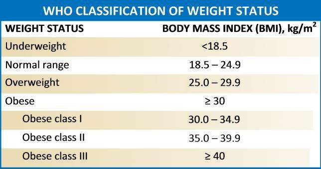

###### [[source](https://www.ncbi.nlm.nih.gov/books/NBK551660/figure/article-35266.image.f1/)]

The following chart can help you identify your estimate of BMI:

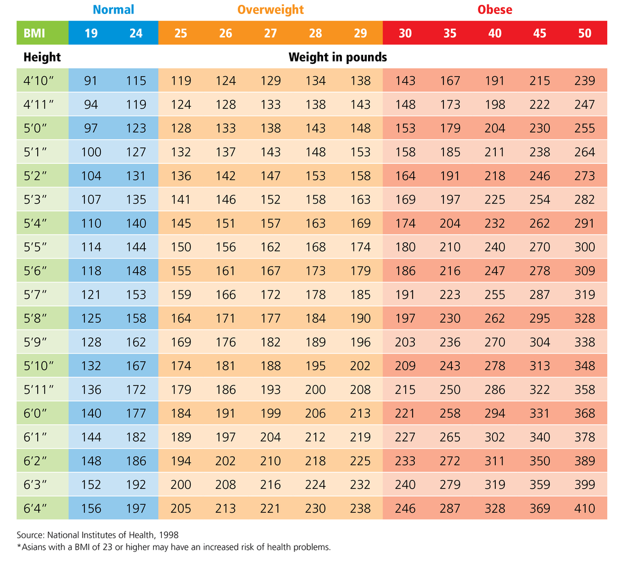

###### [[source](https://www.mayoclinic.org/diseases-conditions/obesity/in-depth/bmi-calculator/itt-20084938)]

Recently, an [article](https://www.nature.com/articles/s41586-019-1171-x.pdf) published in [*Nature*](https://www.nature.com) evaluated and compared the BMI of populations in rural and urban communities around the world:

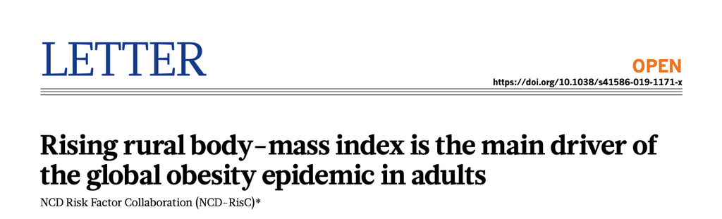

NCD Risk Factor Collaboration (NCD-RisC). Rising rural body-mass index is the main driver of the global obesity epidemic in adults. *Nature* **569**, 260–264 (2019).

The article challenged the widely-held view that increased urbanization was one of the major reasons for increased global obesity rates. This view came about because many countries around the world have shown increased urbanization levels in parallel with increased obesity rates. In this article, however, the NCD-RisC argued that this might not be the case and that in fact for most regions around the world, BMI measurements are increasing in rural populations just as much, if not more so, than urban populations. Furthermore, this study suggested that obesity has particularly increased in female populations in rural regions:

> “We noted a persistently higher rural BMI, especially for women.”

In this case study, we will evaluate the data reported in this article to explore regional and gender specific differences in the obesity rates around the world in 1985 and 2017. Most importantly we will test if there is a difference in obesity rates between rural and urban communities and if there has been a change in obesity over time for these regions, particularly for women. To do this we will test if there is a difference between the average BMI for each group.

## **Main Questions**

**Our main questions are:**

1. Is there a difference between rural and urban BMI estimates around the world? In particular, what does this difference look like for women?
2. How have BMI estimates changed from 1985 to 2017? In particular, what does this change over time look like for women?
3. How do different countries vary in terms of estimates of BMI? In particular, how does the United States compare to the rest of the world?

## **Learning Objectives**

The skills, methods, and concepts that students will be familiar with by the end of this case study are:

**Data science Learning Objectives:**

1. Importing data from a PDF (`pdftools`)
2. Subsetting and filtering data (`dplyr`)
3. Working with character strings (`stringr`)
4. Reshaping data into different formats (`tidyr`)
5. Applying functions to all columns of a tibble (`purrr`)
6. Creating data visualizations (`ggplot2`) with labels (`ggrepel`)
7. Combining multiple plots (`cowplot` and `patchwork`)

**Statistical Learning Objectives:**

1. Familiarity with the use of Quantile-Quantile plots to assess normality
2. Define and understand the utility of alpha and the p value
3. Describe the difference between nonparametric and parametric tests
4. Be able to identify paired data
5. Implementation of a [paired $t$-test](https://www.ncbi.nlm.nih.gov/pmc/articles/PMC5579465/)
6. Interpretation of a [paired $t$-test](https://www.ncbi.nlm.nih.gov/pmc/articles/PMC5579465/)
7. Implementation of a [Wilcoxon signed-rank test](http://www.biostathandbook.com/wilcoxonsignedrank.html) 8.Interpretation of a [Wilcoxon signed-rank test](http://www.biostathandbook.com/wilcoxonsignedrank.html)
8. Understanding of the need for multiple testing correction

In this case study, we will walk you through importing data from a pdf, cleaning, wrangling and visualizing the data, and **comparing two groups** .

We will use well-established and commonly used packages, including `stringr`, `tidyr`, `dplyr`, `purrr`, and `ggplot2` from the [`tidyverse`](https://www.tidyverse.org/). Specifically, the tidyverse is

> “an opinionated collection of R packages designed for data science. All packages share an underlying philosophy and common APIs”.

Another way of putting it is that it’s a set of packages that are useful specifically for data manipulation, exploration, and visualization with a common philosophy. While some students may be familiar with previous packages from the R programming language, these packages make data science in R especially efficient.

[figure not shown]

We will begin by loading the packages that we will need with a brief explanation:

```r
library(here)
library(pdftools)
library(stringr)
library(readr)
library(dplyr)
library(tibble)
library(glue)
library(purrr)
library(tidyr)
library(ggplot2)
library(ggrepel)
library(cowplot)
library(patchwork)
library(OCSdata)
```

**Packages used in this case study:**

| Package | Use in this case study |
| --- | --- |
| here | to easily load and save data with relative paths |
| [pdftools](https://cran.r-project.org/web/packages/pdftools/pdftools.pdf) | to read a text from pdf into R |
| [stringr](https://stringr.tidyverse.org/articles/stringr.html) | to manipulate the text data |
| [readr](https://readr.tidyverse.org/) | to manipulate the text data within the pdf into individual lines |
| [dplyr](https://dplyr.tidyverse.org/) | to arrange/filter/select subsets of the data |
| [tibble](https://tibble.tidyverse.org/) | to create data objects that we can manipulate with `dplyr`/`stringr`/`tidyr`/`purrr` |
| [glue](https://www.tidyverse.org/blog/2017/10/glue-1.2.0/) | to paste or combine character strings and data together |
| [purrr](https://purrr.tidyverse.org/) | to perform functions on all columns of a tibble |
| [tidyr](https://tidyr.tidyverse.org/) | to convert data from ‘wide’ to ‘long’ format |
| [ggplot2](https://ggplot2.tidyverse.org/) | to make visualizations with multiple layers |
| [ggrepel](https://cran.r-project.org/web/packages/ggrepel/vignettes/ggrepel.html) | to allow labels in figures not to overlap |
| [cowplot](https://cran.r-project.org/web/packages/cowplot/vignettes/introduction.html) and patchwork | to allow plots to be combined |
| OCSdata | to access and download OCS data files |

The first time we use a function, we will use the `::` to indicate which package we are using (e.g. `stringr::str_detect()`). Unless we have overlapping function names, this is not necessary, but we will include it here to be informative about where the functions we will use come from.

## **Context**

Previous work has shown higher BMI (>30) is associated with [higher rates of all-causes of mortality](https://www.nhlbi.nih.gov/sites/default/files/media/docs/obesity-evidence-review.pdf), as well as increased rates of type 2 diabetes, cancer, heart disease, and stroke.

However, there appears to be caveats associated with the use of a threshold like this to evaluate public health risk in various populations.

According to this [report](https://pubmed.ncbi.nlm.nih.gov/14726171/):

> …the associations between BMI, percentage of body fat, and body fat distribution differ across populations.

> In particular, in some Asian populations a specific BMI reflects a higher percentage of body fat.

> Some Pacific populations also have a lower percentage of body fat at a given BMI.

> The associations of BMI and comorbidities are probably not stable within populations over time.

##### [[source]](https://pubmed.ncbi.nlm.nih.gov/14726171/)

## **Limitations**

The measurement of BMI has some [limitations](https://www.ncbi.nlm.nih.gov/pmc/articles/PMC4890841/pdf/nt-50-117.pdf) that are well recognized, as it does not account for the composition of body mass, the location of body fat, or the contribution of body frame size. However, [BMI has been a useful health indicator](https://journals.lww.com/acsm-healthfitness/Fulltext/2016/07000/THE_BENEFITS_OF_BODY_MASS_INDEX_AND_WAIST.8.aspx#pdf-link) for risk for many diseases and conditions particularly when combined with other risk factor information.

While [gender](https://www.genderspectrum.org/resources) and [sex](https://www.who.int/genomics/gender/en/index1.html) are not actually binary, the data presented that is used in this analysis only contain data for groups of individuals described as men or women.

## **What are the data?**

We will be using data located within a table of the [supplementary material](https://static-content.springer.com/esm/art%3A10.1038%2Fs41586-019-1171-x/MediaObjects/41586_2019_1171_MOESM1_ESM.pdf) for the NCD-RisC paper referenced above.

You can see that the data contain average BMI estimates for both men and women in countries at the national level, as well as the average BMI estimates for the rural and urban areas of these countries in both 1985 and 2017.

The data within the parentheses are the 95% [credible intervals](https://en.wikipedia.org/wiki/Credible_interval) (CIs) for the average BMI estimates. The authors provide these CIs as a guide to understand how likely the estimate is for the true population mean BMI. A wider range suggests that the estimate is less accurate, as there are more possible values for the true mean with credible evidence. Notice that the mean BMI values are “age-standardised,” which means that the mean values were adjusted for the different age distributions of the various countries so that the countries can be more fairly compared. For example, if one country has a population that is considerably younger, the mean BMI might be quite low (as younger individuals tend to have lower BMI values due to faster metabolic rates). One might falsely conclude that people in that country generally have lower BMI values than people in most other countries, however the lower overall BMI mean might simply be due to the fact that the country has a younger population than those other countries.

## **Data Import**

First let’s download the data from the PDF file. We use `file.exists()` from base R to check if the file we want to download already exists. If not, then we download it using the function `utils::download.file()`. We also use the `here()` function of the `here` package to look specifically in the `raw` subdirectory of the `data` directory of the directory where our open RStudio project file is located. This helps us, as we do not need to write the full path to the document. This makes our code more reproducible for someone else, who may have a different overall file structure on their computer but downloads our case study files from GitHub and therefore has the same file structure specifically for the files included in our GitHub repository. Thus our commands about file locations still work on their local machine.

```r
if(!file.exists(here("data", "raw", "paper_supplement.pdf"))){
  url <- "https://static-content.springer.com/esm/art%3A10.1038%2Fs41586-019-1171-x/MediaObjects/41586_2019_1171_MOESM1_ESM.pdf"
  utils::download.file(url, here("data", "raw", "paper_supplement.pdf"))
}
```

We will save our data to a directory within our working directory called data. We will create subdirectories within this directory to organize our data. We can use the `here` function from the `here` package to make this process easier. The `here()` function allows us to specify the path or location of the document that we want to import, starting from the directory where an `.Rproj` file is located after creating a project in RStudio. In this case, we will import our files within subdirectories of a directory called `raw` of the `data` directory. (*Note the next chunk of code will only work for you if you pull the repository from GitHub and set up your file structure in the same way.*) If you had trouble downloading the data from the orginal sources you can download them from our [GitHub repository for this case study](https://github.com/opencasestudies/ocs-bp-rural-and-urban-obesity/tree/master/data) or use the `OCSdata` package:

```r
# install.packages("OCSdata")
library(OCSdata)
raw_data("ocs-bp-rural-and-urban-obesity", outpath = getwd())
# This will save the pdf file in a "OCSdata/data/raw/" subfolder
# in your current working directory
```

**Click here to see more about creating new projects in RStudio.**

See [here](https://support.rstudio.com/hc/en-us/articles/200526207-Using-Projects) to learn more about using RStudio projects and here to learn more about the `here` package.

Now that we have downloaded the PDF file, we will read it in to R using the `pdftools` package:

```r
pdf_obesity <- pdftools::pdf_text(here("data", "raw", "paper_supplement.pdf"))
```

Let’s take a look at the data – the `summary()` function from base R helps us to look at the structure of R objects.

```r
summary(pdf_obesity)
```

```
   Length  N.unique   N.blank Min.nchar Max.nchar
       63        63         0       108     17528
```

We can see that we have 63 elements that are character strings. You may also notice that the original PDF has 63 pages. Let’s take a look at some of these elements and compare them to the pages in the original document.

```r
pdf_obesity[1] # this looks like the first page
```

```
[1] "Letter                                                                                  https://doi.org/10.1038/s41586-019-1171-x\n\n\n\n\nRising rural body-mass index is the main driver of\nthe global obesity epidemic in adults\nNCD Risk Factor Collaboration (NCD-RisC)*\n\n\n*A list of authors…
```

```r
pdf_obesity[2] # this looks like the second page
```

```
[1] "Supplementary Information. Statistical model for estimating BMI trends by rural and urban\nplace of residence.\n\n\n\n\n                                            1\n"
```

```r
str(pdf_obesity[52], nchar.max = 1600)
```

```
 chr "                                                                               2                                                             2\n                                      Age-standardised mean BMI in 1985 (kg/m )                     Age-standardised mean BMI in 2017 (kg/m )\n       …
```

Yes, this looks like data in the table we want. We are using the `str()` function to print just a portion of the data. The `str()` function compactly displays the structure of arbitrary R objects. The `nchar.max` argument lets us define the maximal number of characters to show. Note `print(pdf_obesity[52])` would show the entire contents of this page of the table.

We can see that the output looks pretty similar to the pages of the pdf, but the spacing is a bit awkward. Note that the way the data is displayed is partially influenced by the width setting of the RStudio window.

Now, we are interested in a supplementary Table 3, which has multiple pages and includes the same header on each page. We can use that to determine what elements of our `pdf_obesity` character strings include our table. We will use the `str_detect()` function from the `stringr` package to search for the elements that contain text that is consistently in the header. The output of of this function will show which elements of the object (in this case pages of the pdf) include this pattern indicated as a `TRUE` or `FALSE`.

```r
stringr::str_detect(pattern = "Age-standardised mean BMI",
                    string = pdf_obesity)
```

```
 [1] FALSE FALSE FALSE FALSE FALSE FALSE FALSE FALSE FALSE FALSE FALSE FALSE
[13] FALSE FALSE FALSE FALSE FALSE FALSE FALSE FALSE FALSE FALSE FALSE FALSE
[25] FALSE FALSE FALSE FALSE FALSE FALSE FALSE FALSE FALSE FALSE FALSE FALSE
[37] FALSE FALSE FALSE FALSE FALSE FALSE FALSE FALSE FALSE FALSE FALSE FALSE
[49] FALSE FALSE FALSE  TRUE  TRUE  TRUE  TRUE  TRUE  TRUE  TRUE  TRUE  TRUE
[61]  TRUE FALSE FALSE
```

We note, the “Age-standardised mean BMI” is part of the header in the table on every page. The code above shows the pages that contain our table of interest (as `TRUE` values).

Now we will extract just the data for the table now and call it `rural_urban`. To do this we will use the `str_subset()` function of the `stringr` package.

```r
rural_urban <- stringr::str_subset(pattern = "Age-standardised mean BMI",
                                   string = pdf_obesity)

summary(rural_urban)
```

```
   Length  N.unique   N.blank Min.nchar Max.nchar
       10        10         0      1636      7891
```

Here, we see there are 10 pages worth of elements in our `rural_urban` object.

Let’s check the first and last page:

```r
str(rural_urban[1], nchar.max = 1600)
```

```
 chr "                                                                               2                                                             2\n                                      Age-standardised mean BMI in 1985 (kg/m )                     Age-standardised mean BMI in 2017 (kg/m )\n       …
```

Using `[1]` shows just the first page of the 10 pages that contain the table. Also, notice the new line `"\n"` values that indicate new lines.

This looks the same as the beginning… how about the end?

```r
str(rural_urban[10], nchar.max = 1800)
```

```
 chr "                                                                                                             2                                                                  2\n                                                                Age-standardised mean BMI in 1985 (kg/m )          …
```

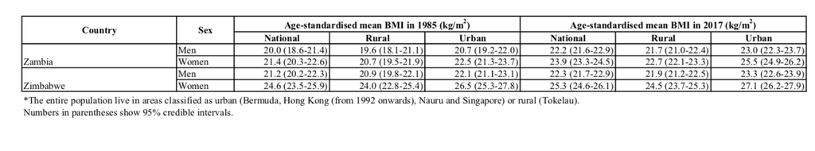

Great! Our `rural_urban` object looks like it contains the entire Supplementary 3 table, as both the beginning and the end include the data we expected.

Now we will save this imported data for later use like so in a subdirectory of the `data` directory called `imported`:

```r
save(rural_urban, file = here::here("data", "imported", "imported_data.rda"))
```